# Detailed Insights: Canarias

## Welcome!

You have reached the CCN Inventory Tool Detailed Insights Report.

Congratulations! This geography has available data.

Potential data availability within the Inventory Tool ranges from Tier I, Tier II, or Tier III Carbon stock estimates.

This is a downloadable document which includes country-specific insights and more detailed analysis, including carbon stocks, emissions factors, and ecosystem wetland area for mangrove, marsh, and seagrass habitats. This report details information for the selected geography, **Canarias**.

Explore the rest of the dashboard for more exciting visualizations, map features, and data.

Resources referenced to calculate Carbon stock estimates for **Canarias** are listed below ‘References’ at the end of this document.

If you have any questions or data you would like to add to the Coastal Carbon Network, please reach out to us at CoastalCarbon@si.edu.

[interactive chart not shown]

## Total Carbon Stock Estimates

Total Carbon stock estimates were calculated for each geography in total, and for mangrove, tidal marsh, and seagrass habitats, if applicable. At this time total Carbon stock estimates for each country do not include seagrass estimates due to the lack of a global, transparent, and independently assessed seagrass habitat map. However, best available areas and stocks for **Canarias** are explored in the following ‘Wetland Areas and Activities’ section.

### Country Level Total Stock Estimates

We estimate that **Canarias** contains between **4116.57** to **2366.34** metric tonnes of soil Carbon to a depth of 1 meter, with a mean estimate of **3241.46** metric tonnes soil Carbon.

Total Geography Level Stocks

| Territory | Country | Habitat | Total Stock | Upper CI | Lower CI | Standard Error |
| --- | --- | --- | --- | --- | --- | --- |
| Canarias | Spain | mangrove | 0 | NA | NA | NA |
| Canarias | Spain | marsh | 3240 | 4116.57 | 2366.34 | 455.79 |
| Canarias | Spain | seagrass | NA | NA | NA | NA |

### Mangrove Estimates

This total estimate includes country-level mangrove carbon stock estimates, with a mean estimate of **0** metric tonnes soil Carbon in mangrove habitats.

## Wetland Areas and Activities

### Mangrove Area

We estimate mangrove area in Canarias to be 0 to 0 hectares with a mean estimate of 0 hectares according to Global Mangrove Watch, Bunting et al 2018.

### Tidal Marsh Area

We estimate tidal marsh area in Canarias to be 7.7 to 14.37 hectares with a mean estimate of 12.7116 hectares according to Worthington et al 2024.

### Seagrass Area

We estimate seagrass area in Canarias to be approximately 0 hectares according to McKenzie et al 2020.

## Calculated Stocks and Emissions Factors

This section of the report details whether data is available to estimate Tier I, Tier II, or Tier III value estimates for tidal marsh, mangrove, and seagrass ecosystems in **Canarias**.

If data for the selected country is available in the Coastal Carbon Atlas, we have applied a Tier II emission factor based on a simple average of country specific data queried from the Atlas.

IPCC Tier I Value Estimates

| Habitat | Mean | Lower CI | Upper CI |
| --- | --- | --- | --- |
| mangrove | 386 | 351 | 424 |
| marsh | 255 | 254 | 297 |
| seagrass | 108 | 84 | 139 |

### Tier I Carbon Stocks

This table includes Tier I Soil Carbon Stocks included for **Canarias**.

| Territory | Country | Habitat | Mean Stock (MgHa) | Lower CI | Upper CI |
| --- | --- | --- | --- | --- | --- |
| Canarias | Spain | mangrove | 386 | 351 | 424 |
| Canarias | Spain | marsh | 255 | 254 | 297 |
| Canarias | Spain | seagrass | 108 | 84 | 139 |

### Tier II Carbon Stocks

Tier II carbon stocks were estimated, when available, from soil core data currently housed in the Coastal Carbon Atlas.

Tier II Data Availability for **Canarias**: The selected geography, **Canarias** does not currently have available Tier II carbon stock estimates at a depth of 1 meter. Please refer to Tier I values.

### Tier III Carbon Stocks

Tier III carbon stocks were estimated, when available, from remote sensing data from Maxwell et al 2021 for mangrove habitats, and Sanderman et al 2018 for tidal marsh habitats. The following details whether estimated values are available for **Canarias**, and any overlap with associated Tier I or Tier II values.

If there are no Tier III estimates associated with the selected country, please refer to Tier I and/or Tier II tables.

Tier III Data Availability for **Canarias**: There are currently no Tier III values for **Canarias** in the CCN Inventory Dashboard. Please refer to Tier I values.

## Visualizations

### 2. Emissions Factors

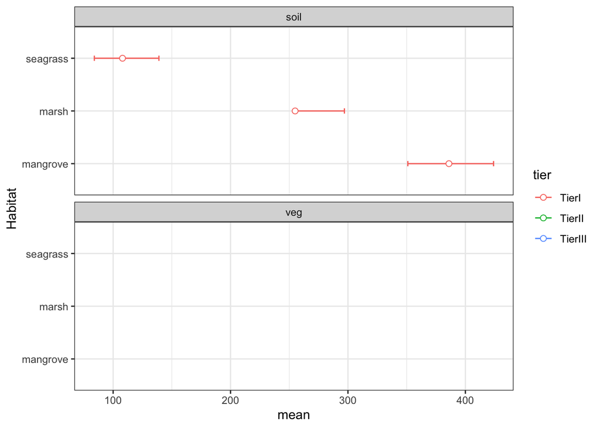

### 3. Activity Data

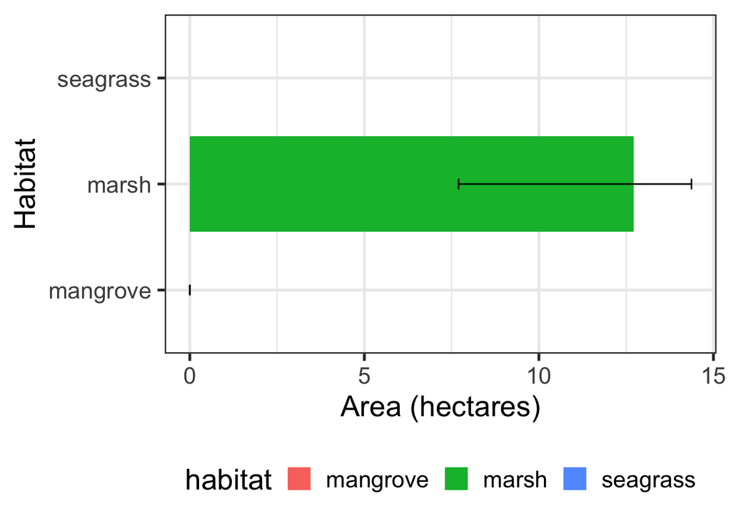

## References

BarrÃn, Cristina, NÃria Mar ’e, Jorge Terrados, Hilary Kennedy, and Carlos M. Duarte. 2004. “Community Metabolism and Carbon Budget Along a Gradient of Seagrass (Cymodocea Nodosa ) Colonization.” *Limnology and Oceanography* 49 (5): 1642–51. https://doi.org/10.4319/lo.2004.49.5.1642.

Belshe, E. Fay, Jose Sanjuan, Carmen Leiva-Dueñas, Nerea Piñeiro-Juncal, Oscar Serrano, Paul Lavery, and Miguel Angel Mateo. 2019. “Modeling Organic Carbon Accumulation Rates and Residence Times in Coastal Vegetated Ecosystems.” *Journal of Geophysical Research: Biogeosciences* 124 (11): 3652–71. https://doi.org/10.1029/2019jg005233.

Bunting, Pete, Ake Rosenqvist, Richard M. Lucas, Lisa-Maria Rebelo, Lammert Hilarides, Nathan Thomas, Andy Hardy, Takuya Itoh, Masanobu Shimada, and C. Max Finlayson. 2018. “The Global Mangrove Watch—a New 2010 Global Baseline of Mangrove Extent.” *Remote Sensing* 10 (10): 1669. https://doi.org/10.3390/rs10101669.

Calleja, Maria Ll., NÃria Mar ‘a, and Carlos M. Duarte. 2007. “The Relationship Between Seagrass (Posidonia Oceanica) Decline and Sulfide Porewater Concentration in Carbonate Sediments.” *Estuarine, Coastal and Shelf Science* 73 (July): 583–88. https://doi.org/10.1016/j.ecss.2007.02.016.

Camacho, Sarita, Delminda Moura, Simon Connor, Tomasz Boski, and Ana Gomes. 2014. “Geochemical Characteristics of Sediments Along the Margins of an Atlantic-Mediterranean Estuary (the Guadiana, Southeast Portugal): Spatial and Seasonal Variations.” *Revista de Gestão Costeira Integrada* 14 (1): 129–48. https://doi.org/10.5894/rgci452.

de los Santos, Carmen B., Luis G. Egea, M’arcio Martins, Rui Santos, Pere Masqu’e, Gloria Peralta, Fernando G. Brun, and Roc’ıo Jim’enez-Ramos. 2022. “Sedimentary Organic Carbon and Nitrogen Sequestration Across a Vertical Gradient on a Temperate Wetland Seascape Including Salt Marshes, Seagrass Meadows and Rhizophytic Macroalgae Beds.” *Ecosystems* 26 (4): 826–42. https://doi.org/10.1007/s10021-022-00801-5.

E. Fay Belshe, Jose Sanjuan, Carmen Leiva-Dueñas, Nerea Piñeiro-Juncal, Oscar Serrano, Paul S. Lavery, and Miguel Angel Mateo. 2019. “Dataset: Modeling Organic Carbon Accumulation Rates and Residence Times in Coastal Vegetated Ecosystems.” The Smithsonian Institution. https://doi.org/10.25573/DATA.9856769.

Fourqurean, James W., Carlos M. Duarte, Hilary Kennedy, NÃria Mar ‘a, Marianne Holmer, Miguel Angel Mateo, Eugenia T. Apostolaki, et al. 2012a. “Seagrass Ecosystems as a Globally Significant Carbon Stock.” *Nature Geoscience* 5 (7): 505–9. https://doi.org/10.1038/ngeo1477.

———, et al. 2012b. “Seagrass Ecosystems as a Globally Significant Carbon Stock.” *Nature Geoscience* 5 (7): 505–9. https://doi.org/10.1038/ngeo1477.

———, et al. 2012c. “Seagrass Ecosystems as a Globally Significant Carbon Stock.” *Nature Geoscience* 5 (7): 505–9. https://doi.org/10.1038/ngeo1477.

———, et al. 2012d. “Seagrass Ecosystems as a Globally Significant Carbon Stock.” *Nature Geoscience* 5 (7): 505–9. https://doi.org/10.1038/ngeo1477.

———, et al. 2012e. “Seagrass Ecosystems as a Globally Significant Carbon Stock.” *Nature Geoscience* 5 (7): 505–9. https://doi.org/10.1038/ngeo1477.

———, et al. 2012f. “Seagrass Ecosystems as a Globally Significant Carbon Stock.” *Nature Geoscience* 5 (7): 505–9. https://doi.org/10.1038/ngeo1477.

———, et al. 2012g. “Seagrass Ecosystems as a Globally Significant Carbon Stock.” *Nature Geoscience* 5 (7): 505–9. https://doi.org/10.1038/ngeo1477.

———, et al. 2012h. “Seagrass Ecosystems as a Globally Significant Carbon Stock.” *Nature Geoscience* 5 (7): 505–9. https://doi.org/10.1038/ngeo1477.

———, et al. 2012i. “Seagrass Ecosystems as a Globally Significant Carbon Stock.” *Nature Geoscience* 5 (7): 505–9. https://doi.org/10.1038/ngeo1477.

———, et al. 2012j. “Seagrass Ecosystems as a Globally Significant Carbon Stock.” *Nature Geoscience* 5 (7): 505–9. https://doi.org/10.1038/ngeo1477.

———, et al. 2012k. “Seagrass Ecosystems as a Globally Significant Carbon Stock.” *Nature Geoscience* 5 (7): 505–9. https://doi.org/10.1038/ngeo1477.

———, et al. 2012l. “Seagrass Ecosystems as a Globally Significant Carbon Stock.” *Nature Geoscience* 5 (7): 505–9. https://doi.org/10.1038/ngeo1477.

———, et al. 2012m. “Seagrass Ecosystems as a Globally Significant Carbon Stock.” *Nature Geoscience* 5 (7): 505–9. https://doi.org/10.1038/ngeo1477.

———, et al. 2012n. “Seagrass Ecosystems as a Globally Significant Carbon Stock.” *Nature Geoscience* 5 (7): 505–9. https://doi.org/10.1038/ngeo1477.

———, et al. 2012o. “Seagrass Ecosystems as a Globally Significant Carbon Stock.” *Nature Geoscience* 5 (7): 505–9. https://doi.org/10.1038/ngeo1477.

———, et al. 2012p. “Seagrass Ecosystems as a Globally Significant Carbon Stock.” *Nature Geoscience* 5 (7): 505–9. https://doi.org/10.1038/ngeo1477.

———, et al. 2012q. “Seagrass Ecosystems as a Globally Significant Carbon Stock.” *Nature Geoscience* 5 (7): 505–9. https://doi.org/10.1038/ngeo1477.

Gacia, EsperanÃ§a, Carlos M. Duarte, and Jack J. Middelburg. 2002a. “Carbon and Nutrient Deposition in a Mediterranean Seagrass (Posidonia Oceanica) Meadow.” *Limnology and Oceanography* 47 (1): 23–32. https://doi.org/10.4319/lo.2002.47.1.0023.

———. 2002b. “Carbon and Nutrient Deposition in a Mediterranean Seagrass (Posidonia Oceanica) Meadow.” *Limnology and Oceanography* 47 (1): 23–32. https://doi.org/10.4319/lo.2002.47.1.0023.

Gonz’alez-Alcaraz, M. N., B. Ar’anega, H. M. Conesa, M. J. Delgado, and J. ’Alvarez-Rogel. 2015. “Contribution of Soil Properties to the Assessment of a Seawater Irrigation Programme as a Management Strategy for Abandoned Solar Saltworks.” *CATENA* 126 (March): 189–200. https://doi.org/10.1016/j.catena.2014.11.012.

Holmer, Marianne, NÃria Mar ‘a, Morgane Lamote, and Carlos M. Duarte. 2009a. “Deterioration of Sediment Quality in Seagrass Meadows (Posidonia Oceanica) Invaded by Macroalgae (Caulerpa Sp.).” *Estuaries and Coasts* 32 (3): 456–66. https://doi.org/10.1007/s12237-009-9133-4.

———. 2009b. “Deterioration of Sediment Quality in Seagrass Meadows (Posidonia Oceanica) Invaded by Macroalgae (Caulerpa Sp.).” *Estuaries and Coasts* 32 (3): 456–66. https://doi.org/10.1007/s12237-009-9133-4.

Holmer, Marianne, Carlos M. Duarte, and NÃria Mar ’a. 2003a. “Sulfur Cycling and Seagrass (Posidonia Oceanica) Status in Carbonate Sediments.” *Biogeochemistry* 66 (3): 223–39. https://doi.org/10.1023/b:biog.0000005326.35071.51.

———. 2003b. “Sulfur Cycling and Seagrass (Posidonia Oceanica) Status in Carbonate Sediments.” *Biogeochemistry* 66 (3): 223–39. https://doi.org/10.1023/b:biog.0000005326.35071.51.

Holmer, Marianne, and Morten S. Frederiksen. 2007a. “Stimulation of Sulfate Reduction Rates in Mediterranean Fish Farm Sediments Inhabited by the Seagrass Posidonia Oceanica.” *Biogeochemistry* 85 (2): 169–84. https://doi.org/10.1007/s10533-007-9127-x.

———. 2007b. “Stimulation of Sulfate Reduction Rates in Mediterranean Fish Farm Sediments Inhabited by the Seagrass Posidonia Oceanica.” *Biogeochemistry* 85 (2): 169–84. https://doi.org/10.1007/s10533-007-9127-x.

Kumar, Mukesh, Tomasz Boski, Francisco J. Gonz’alez-Vila, Nicasio T. Jim’enez-Morillo, and Jos’e A. Gonz’alez-P’erez. 2020a. “Characteristics of Organic Matter Sources from Guadiana Estuary Salt Marsh Sediments (SW Iberian Peninsula).” *Continental Shelf Research* 197 (June): 104076. https://doi.org/10.1016/j.csr.2020.104076.

———. 2020b. “Characteristics of Organic Matter Sources from Guadiana Estuary Salt Marsh Sediments (SW Iberian Peninsula).” *Continental Shelf Research* 197 (June): 104076. https://doi.org/10.1016/j.csr.2020.104076.

Mateo, M. A., J. Romero, M. PÃrez, M. M. Littler, and D. S. Littler. 1997. “Dynamics of Millenary Organic Deposits Resulting from the Growth of the Mediterranean SeagrassPosidonia Oceanica.” *Estuarine, Coastal and Shelf Science* 44 (1): 103–10. https://doi.org/10.1006/ecss.1996.0116.

Maxwell, Tania L., Andr’e S. Rovai, Maria Fernanda Adame, Janine B. Adams, Jos’e ’Alvarez-Rogel, William E. N. Austin, Kim Beasy, et al. 2023a. “Global Dataset of Soil Organic Carbon in Tidal Marshes.” *Scientific Data* 10 (1). https://doi.org/10.1038/s41597-023-02633-x.

———, et al. 2023b. “Global Dataset of Soil Organic Carbon in Tidal Marshes.” *Scientific Data* 10 (1). https://doi.org/10.1038/s41597-023-02633-x.

———, et al. 2023c. “Global Dataset of Soil Organic Carbon in Tidal Marshes.” *Scientific Data* 10 (1). https://doi.org/10.1038/s41597-023-02633-x.

———, et al. 2023d. “Global Dataset of Soil Organic Carbon in Tidal Marshes.” *Scientific Data* 10 (1). https://doi.org/10.1038/s41597-023-02633-x.

———, et al. 2023e. “Global Dataset of Soil Organic Carbon in Tidal Marshes.” *Scientific Data* 10 (1). https://doi.org/10.1038/s41597-023-02633-x.

———, et al. 2023f. “Global Dataset of Soil Organic Carbon in Tidal Marshes.” *Scientific Data* 10 (1). https://doi.org/10.1038/s41597-023-02633-x.

Maxwell, Tania L., Andr’e S Rovai, Maria Fernanda Adame, Janine B. Adams, Jos’e ’Alvarez-Rogel, William E. N. Austin, Kim Beasy, et al. 2023g. “Database: Tidal Marsh Soil Organic Carbon (MarSOC) Dataset.” Zenodo. https://doi.org/10.5281/ZENODO.8414110.

———, et al. 2023h. “Database: Tidal Marsh Soil Organic Carbon (MarSOC) Dataset.” Zenodo. https://doi.org/10.5281/ZENODO.8414110.

———, et al. 2023i. “Database: Tidal Marsh Soil Organic Carbon (MarSOC) Dataset.” Zenodo. https://doi.org/10.5281/ZENODO.8414110.

———, et al. 2023j. “Database: Tidal Marsh Soil Organic Carbon (MarSOC) Dataset.” Zenodo. https://doi.org/10.5281/ZENODO.8414110.

———, et al. 2023k. “Database: Tidal Marsh Soil Organic Carbon (MarSOC) Dataset.” Zenodo. https://doi.org/10.5281/ZENODO.8414110.

———, et al. 2023l. “Database: Tidal Marsh Soil Organic Carbon (MarSOC) Dataset.” Zenodo. https://doi.org/10.5281/ZENODO.8414110.

Mazarrasa, In’es, Joao M. Neto, Tjeerd J. Bouma, Tim Grandjean, Jordi Garcia-Orellana, Pere Masqu’e, Mar’ıa Recio, ’Oscar Serrano, Araceli Puente, and Jos’e A. Juanes. 2023. “Drivers of Variability in Blue Carbon Stocks and Burial Rates Across European Estuarine Habitats.” *Science of The Total Environment* 886 (August): 163957. https://doi.org/10.1016/j.scitotenv.2023.163957.

McKenzie, Len J, Lina M Nordlund, Benjamin L Jones, Leanne C Cullen-Unsworth, Chris Roelfsema, and Richard K F Unsworth. 2020. “The Global Distribution of Seagrass Meadows.” *Environmental Research Letters* 15 (7): 074041. https://doi.org/10.1088/1748-9326/ab7d06.

UNEP-WCMC, and FT Short. 2018. “Global Distribution of Seagrasses (Version 6.0).” UN Environment Programme World Conservation Monitoring Centre. https://wedocs.unep.org/bitstream/handle/20.500.11822/34031/GDS.pdf?sequence=1&isAllowed=y.

Van Engeland, and T. 2010. “Dissolved Organic Nitrogen Dynamics in Coastal Ecosystems.” PhD thesis, Utrecht University. https://dspace.library.uu.nl/handle/1874/41801.

Worthington, Thomas A., Mark Spalding, Emily Landis, Tania L. Maxwell, Alejandro Navarro, Lindsey S. Smart, and Nicholas J. Murray. 2024. “The Distribution of Global Tidal Marshes from Earth Observation Data.” *Global Ecology and Biogeography* 33 (8). https://doi.org/10.1111/geb.13852.